# Does recent rain cool September in Bangalore?

2026-09-12

## Question

Can we analyse the relationship between rain and heat in September using past years’ data ? Like this year has been hot and dry. We need to oook at temperature in September as a finction of rain in the last few days or something. Wonder if some signal exists.

## Analysis contract

- **Unit:** one September calendar day.
- **Heat:** daily maximum temperature (the clearest measure of daytime heat); minimum temperature is checked separately because rain can cool afternoons while keeping nights warmer.
- **Rain exposure:** rain on the same day, plus cumulative rain in the preceding 1, 3, and 7 days. The lagged windows avoid treating rain that falls after the day’s heat as if it caused that heat.
- **Comparison:** complete September days in 1981–2025, with temperature expressed as an anomaly from the historical average for that calendar day. This removes the small within-September seasonal trend. The incomplete current September is evaluated descriptively against the same September 1–11 window in prior years; September 12 is excluded because the archive row may still be a partial day.
- **What this cannot show:** a causal effect of rain. Large-scale weather patterns, cloud cover, wind and humidity also affect temperature, and rain itself is not randomly assigned.

## Data preparation and checks

```r
load(file.path(root_dir, "data", "bangaloreTemperature.RData"))
load(file.path(root_dir, "data", "bangaloreRainfall.RData"))

temp_daily <- blrTemp %>%
  transmute(date = as.Date(DT), temp_c = as.numeric(Temp)) %>%
  group_by(date) %>%
  summarise(tmax = max(temp_c, na.rm = TRUE),
            tmin = min(temp_c, na.rm = TRUE), .groups = "drop")
rain_daily <- blrRain %>%
  transmute(date = as.Date(DT), rain_mm = as.numeric(Rain)) %>%
  group_by(date) %>%
  summarise(rain_mm = sum(rain_mm, na.rm = TRUE), .groups = "drop")

daily <- temp_daily %>%
  left_join(rain_daily, by = "date") %>%
  mutate(year = year(date), month = month(date), day = day(date)) %>%
  arrange(date) %>%
  group_by(year) %>%
  mutate(rain_prev_1d = lag(rain_mm, 1, default = 0),
         rain_prev_3d = lag(rain_mm, 1, default = 0) + lag(rain_mm, 2, default = 0) + lag(rain_mm, 3, default = 0),
         rain_prev_7d = lag(rain_mm, 1, default = 0) + lag(rain_mm, 2, default = 0) + lag(rain_mm, 3, default = 0) +
                       lag(rain_mm, 4, default = 0) + lag(rain_mm, 5, default = 0) + lag(rain_mm, 6, default = 0) + lag(rain_mm, 7, default = 0)) %>%
  ungroup() %>%
  filter(month == 9, !is.na(tmax), !is.na(tmin), !is.na(rain_mm))

historical <- daily %>% filter(year <= 2025)
current <- daily %>% filter(year == 2026, day <= 11)

climatology <- historical %>%
  group_by(day) %>%
  summarise(tmax_clim = mean(tmax), tmin_clim = mean(tmin), .groups = "drop")
historical <- historical %>% left_join(climatology, by = "day") %>%
  mutate(tmax_anom = tmax - tmax_clim, tmin_anom = tmin - tmin_clim)
current <- current %>% left_join(climatology, by = "day") %>%
  mutate(tmax_anom = tmax - tmax_clim, tmin_anom = tmin - tmin_clim)

list(historical_days = nrow(historical), historical_years = n_distinct(historical$year),
     current_days = nrow(current), current_last_date = max(current$date),
     duplicate_dates = nrow(daily) - n_distinct(daily$date))
```

```
## $historical_days
## [1] 1350
##
## $historical_years
## [1] 45
##
## $current_days
## [1] 11
##
## $current_last_date
## [1] "2026-09-11"
##
## $duplicate_dates
## [1] 0
```

## Is there a signal?

The association is negative for daytime heat: September days with more rain in the preceding week tend to have lower-than-usual maximum temperatures. The relationship is not strong enough to predict a day’s temperature by itself, however.

```r
lag_vars <- c("rain_mm", "rain_prev_1d", "rain_prev_3d", "rain_prev_7d")
lag_labels <- c("Same-day rain", "Rain in prior 1 day", "Rain in prior 3 days", "Rain in prior 7 days")
correlation_tbl <- map2_dfr(lag_vars, lag_labels, ~{
  z <- historical %>% select(tmax_anom, tmin_anom, all_of(.x)) %>% drop_na()
  tibble(window = .y,
         n = nrow(z),
         tmax_r = cor(z$tmax_anom, z[[.x]]),
         tmin_r = cor(z$tmin_anom, z[[.x]]),
         tmax_slope_per_10mm = coef(lm(tmax_anom ~ I(z[[.x]] / 10), data = z))[2],
         tmax_r2 = summary(lm(tmax_anom ~ I(z[[.x]] / 10), data = z))$r.squared)
})
correlation_tbl
```

```
## # A tibble: 4 × 6
##   window                   n tmax_r tmin_r tmax_slope_per_10mm tmax_r2
##   <chr>                <int>  <dbl>  <dbl>               <dbl>   <dbl>
## 1 Same-day rain         1350 -0.144  0.164              -0.295  0.0209
## 2 Rain in prior 1 day   1350 -0.207  0.161              -0.429  0.0429
## 3 Rain in prior 3 days  1350 -0.203  0.204              -0.185  0.0413
## 4 Rain in prior 7 days  1350 -0.225  0.226              -0.116  0.0507
```

For the main daytime measure, the preceding 7-day total has the clearest simple association: the correlation is -0.23 and the fitted slope is about -0.12 °C per additional 10 mm of recent rain. The 0.05 R-squared means that most day-to-day variation is still explained by other factors.

## What does that mean for 2026?

```r
historical_same_window <- historical %>%
  filter(day <= 11) %>%
  group_by(year) %>%
  summarise(tmax = mean(tmax), tmin = mean(tmin), rain = mean(rain_mm),
            tmax_anom = mean(tmax_anom), .groups = "drop")
current_summary <- current %>%
  summarise(days = n(), mean_tmax = mean(tmax), mean_tmin = mean(tmin),
            mean_rain = mean(rain_mm), mean_tmax_anom = mean(tmax_anom),
            wet_days = sum(rain_mm > 1))
current_summary
```

```
## # A tibble: 1 × 6
##    days mean_tmax mean_tmin mean_rain mean_tmax_anom wet_days
##   <int>     <dbl>     <dbl>     <dbl>          <dbl>    <int>
## 1    11      31.0      21.6     0.172           3.45        0
```

```r
historical_same_window %>% summarise(
  historical_mean_tmax = mean(tmax), historical_mean_tmin = mean(tmin),
  historical_mean_rain = mean(rain), historical_mean_tmax_anom = mean(tmax_anom),
  current_percentile_tmax = mean(tmax <= current_summary$mean_tmax) * 100,
  current_percentile_rain = mean(rain >= current_summary$mean_rain) * 100)
```

```
## # A tibble: 1 × 6
##   historical_mean_tmax historical_mean_tmin historical_mean_rain
##                  <dbl>                <dbl>                <dbl>
## 1                 27.5                 20.0                 3.89
## # ℹ 3 more variables: historical_mean_tmax_anom <dbl>,
## #   current_percentile_tmax <dbl>, current_percentile_rain <dbl>
```

In September 2026 through the 11th, the mean maximum temperature was 31 °C versus 27.5 °C in the same window of earlier years. Mean daily rain was only 0.17 mm, versus 3.89 mm historically. That is consistent with “hot and dry,” but it is a short, incomplete-month comparison rather than a full September ranking.

## Binned view

```r
bins <- historical %>%
  mutate(rain7_bin = cut(rain_prev_7d,
                         breaks = c(-Inf, 5, 15, 25, 50, Inf),
                         labels = c("≤5 mm", ">5–15 mm", ">15–25 mm", ">25–50 mm", ">50 mm"),
                         right = TRUE)) %>%
  group_by(rain7_bin) %>%
  summarise(days = n(), mean_tmax_anom = mean(tmax_anom), median_tmax_anom = median(tmax_anom),
            mean_tmin_anom = mean(tmin_anom), .groups = "drop")
bins
```

```
## # A tibble: 5 × 5
##   rain7_bin  days mean_tmax_anom median_tmax_anom mean_tmin_anom
##   <fct>     <int>          <dbl>            <dbl>          <dbl>
## 1 ≤5 mm       209          0.595            0.698        -0.430
## 2 >5–15 mm    318          0.279            0.194        -0.0792
## 3 >15–25 mm   245         -0.132           -0.124         0.0316
## 4 >25–50 mm   319         -0.287           -0.366         0.140
## 5 >50 mm      259         -0.345           -0.141         0.242
```

## Chart: show the relationship directly

The main question is continuous, so the chart should keep rainfall continuous too. Each faint point is one historical September day. The smooth line summarizes the broad association without hiding the large amount of unexplained day-to-day variation. The current September observations are overlaid in a contrasting colour.

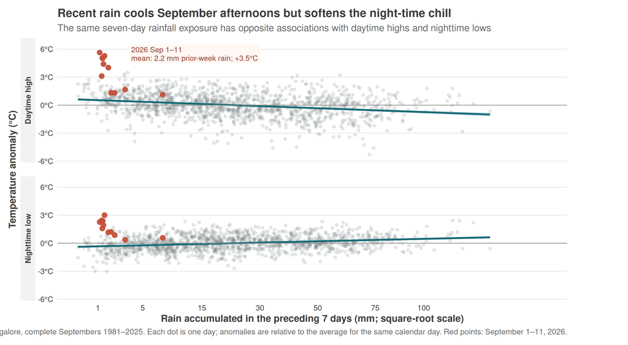

```r
historical_plot <- bind_rows(
  historical %>% transmute(rain_prev_7d, anomaly = tmax_anom, measure = "Daytime high"),
  historical %>% transmute(rain_prev_7d, anomaly = tmin_anom, measure = "Nighttime low")
) %>% mutate(measure = factor(measure, levels = c("Daytime high", "Nighttime low")))
current_plot <- bind_rows(
  current %>% transmute(rain_prev_7d, anomaly = tmax_anom, measure = "Daytime high"),
  current %>% transmute(rain_prev_7d, anomaly = tmin_anom, measure = "Nighttime low")
) %>% mutate(measure = factor(measure, levels = c("Daytime high", "Nighttime low")))
current_anchor <- current %>%
  summarise(x = 3.5, y = 5.5,
            label = paste0("2026 Sep 1–11\nmean: ", round(mean(rain_prev_7d), 1),
                           " mm prior-week rain; ",
                           ifelse(mean(tmax_anom) >= 0, "+", ""), round(mean(tmax_anom), 1), "°C")) %>%
  mutate(measure = factor("Daytime high", levels = c("Daytime high", "Nighttime low")))
chart_path <- file.path(chart_dir, "september-rain-heat-lag.png")
p <- ggplot() +
  geom_point(data = historical_plot, aes(rain_prev_7d, anomaly),
             color = "#6F7678", alpha = 0.16, size = 1.25) +
  geom_smooth(data = historical_plot, aes(rain_prev_7d, anomaly),
              method = "lm", formula = y ~ x, se = TRUE,
              color = "#176B78", fill = "#176B78", alpha = 0.16, linewidth = 1.0) +
  geom_hline(yintercept = 0, color = "grey55", linewidth = 0.35) +
  geom_point(data = current_plot, aes(rain_prev_7d, anomaly),
             color = "#C4513A", size = 2.4, alpha = 0.95) +
  geom_label(data = current_anchor,
             aes(x = x, y = y, label = label),
             hjust = 0, vjust = 0.5, size = 3.0, lineheight = 0.95,
             label.size = 0, fill = "#FFF7F3", color = "#8E3C2D") +
  facet_grid(measure ~ ., scales = "fixed", switch = "y") +
  scale_x_sqrt(name = "Rain accumulated in the preceding 7 days (mm; square-root scale)",
               breaks = c(1, 5, 15, 30, 50, 75, 100),
               labels = label_number(accuracy = 1),
               limits = c(0, NA), expand = expansion(mult = c(0.01, 0.18))) +
  scale_y_continuous(name = "Temperature anomaly (°C)",
                     labels = label_number(suffix = "°C"),
                     expand = expansion(mult = c(0.08, 0.14))) +
  labs(title = "Recent rain cools September afternoons but softens the night-time chill",
       subtitle = "The same seven-day rainfall exposure has opposite associations with daytime highs and nighttime lows",
       caption = "Bangalore, complete Septembers 1981–2025. Each dot is one day; anomalies are relative to the average for the same calendar day. Red points: September 1–11, 2026.") +
  theme_weather() +
  theme(axis.title = element_text(color = "#3C3C3C", face = "bold"),
        axis.text = element_text(face = "plain"),
        strip.text = element_text(face = "bold", color = "#3C3C3C"),
        strip.placement = "outside",
        strip.background = element_rect(fill = "grey95", color = NA),
        panel.spacing = unit(1.1, "lines"),
        plot.margin = margin(10, 70, 10, 10))
p
```

```r
ggsave(chart_path, p, width = 11.5, height = 8.5, dpi = 180, bg = "white")
```

## Checks and interpretation

- The main result uses a 7-day cumulative window, but the sign is similar for same-day and 1-/3-day windows. This is a robustness check, not a claim that seven days is a uniquely correct lag.
- Temperature is residualized by calendar day, so the result is not just “September gets cooler later.”
- A rain-temperature association is not causal: the same synoptic situation can produce cloud, rain, wind and cooler maximum temperature.
- The 2026 comparison excludes September 12 because the current-day archive may be incomplete. It should be rerun after the month ends for a complete comparison.

## Verdict

Insightful: yes

There is a real but modest signal: wetter conditions in the preceding few days are associated with cooler September daytime highs in Bangalore, while recent rain is associated with slightly warmer nights. The strongest simple relationship is with rain accumulated over the previous week, but it explains only about 5.1% of daily daytime-temperature variation. September 2026 through September 11 is both warmer and much drier than the historical September 1–11 baseline, consistent with the proposed “hot and dry” description; the result is descriptive and should be updated after the month is complete.

Charts:

- `docs/assets/analysis/september-rain-heat-lag.png`

Blog post:

- not published; await explicit `/weather_publish september-rain-heat-lag`